# Copy_of_Exercise_2_1_(1)

1. Train and compare the MLP from Assignment 1 and a simple CNN on the CIFAR-10 dataset (available in PyTorch) with somewhat optimized hyper-parameters

```python
import os
import numpy as np
import torch
import torch.nn as nn
import torchvision.transforms as transforms
import torchvision.datasets as datasets
import matplotlib.pyplot as plt
from tqdm import tqdm
```

```python
# Retrieving the CIFAR-10 dataset as training and testing sets
train_dataset = datasets.CIFAR10(root='./data', train=True, transform=transforms.ToTensor(), download=True)
test_dataset = datasets.CIFAR10(root='./data', train=False, transform=transforms.ToTensor(), download=True)
```

```
Files already downloaded and verified
Files already downloaded and verified
```

```python
n_imgs_train = len(train_dataset)
n_imgs_test = len(test_dataset)
```

```python
print(f"# Images Train: {n_imgs_train}")
print(f"# Images Test:  {n_imgs_test}")
```

```
# Images Train: 50000
# Images Test:  10000
```

```python
img_shape = train_dataset[0][0].shape
label = train_dataset[0][1]

print(f"Image shape: {img_shape}")
print(f"Label: {label}")
```

```
Image shape: torch.Size([3, 32, 32])
Label: 6
```

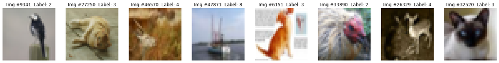

```python
N_IMGS = 8
fig, ax = plt.subplots(1,N_IMGS)
fig.set_size_inches(3 * N_IMGS, 3)

ids = np.random.randint(low=0, high=len(train_dataset), size=N_IMGS)

for i, n in enumerate(ids):
    img = train_dataset[n][0].numpy().reshape(3,32,32).transpose(1,2,0)
    ax[i].imshow(img)
    ax[i].set_title(f"Img #{n}  Label: {train_dataset[n][1]}")
    ax[i].axis("off")
plt.show()
```

```python
BATCH_SIZE = 64
SHUFFLE_TRAIN = True
```

```python
train_loader =  torch.utils.data.DataLoader(
        dataset=train_dataset,
        batch_size=BATCH_SIZE,
        shuffle=SHUFFLE_TRAIN
    )

eval_loader =  torch.utils.data.DataLoader(
        dataset=test_dataset,
        batch_size=BATCH_SIZE,
        shuffle=False
    )
```

```python
imgs, labels = next(iter(eval_loader))
print(f"imgs.shape = {imgs.shape}")
print(f"labels.shape = {labels.shape}")
```

```
imgs.shape = torch.Size([64, 3, 32, 32])
labels.shape = torch.Size([64])
```

```python
for i, (imgs, labels) in enumerate(eval_loader):
    print(f"Iterating batch #{i+1}, which has {len(labels)} elements")
    if i > 10:
        break
```

```
Iterating batch #1, which has 64 elements
Iterating batch #2, which has 64 elements
Iterating batch #3, which has 64 elements
Iterating batch #4, which has 64 elements
Iterating batch #5, which has 64 elements
Iterating batch #6, which has 64 elements
Iterating batch #7, which has 64 elements
Iterating batch #8, which has 64 elements
Iterating batch #9, which has 64 elements
Iterating batch #10, which has 64 elements
Iterating batch #11, which has 64 elements
Iterating batch #12, which has 64 elements
```

**MLP Model**

```python
class Model(nn.Module):
    """
    MLP composed of two fully connected layers.
     - First layer takes pixel values and maps them to a hidden dimension
     - Nonlinear activation
     - Second layer maps from hidden dimension to number of classes, predicting a score for each of the classes
    """
    def __init__(self, input_dim=3072, hidden_dim=512, output_dim=10):
        """ Model initalizer """
        super().__init__()
        self.layers = nn.Sequential(
                nn.Linear(in_features=input_dim, out_features=hidden_dim),
                nn.ReLU(),
                nn.Linear(in_features=hidden_dim, out_features=output_dim)
            )

    def forward(self, x):
        """ Forward pass through the model"""
        assert len(x.shape) == 2, f"ERROR! Shape of input must be 2D (b_size, dim)"
        pred = self.layers(x)
        return pred

def count_model_params(model):
    """ Counting the number of learnable parameters in a nn.Module """
    num_params = sum(p.numel() for p in model.parameters() if p.requires_grad)
    return num_params
```

```python
model = Model(input_dim=3072, hidden_dim=512, output_dim=10)
print(model)
```

```
Model(
  (layers): Sequential(
    (0): Linear(in_features=3072, out_features=512, bias=True)
    (1): ReLU()
    (2): Linear(in_features=512, out_features=10, bias=True)
  )
)
```

```python
imgs, labels = next(iter(eval_loader))      # sampling images
flattened_imgs = imgs.flatten(start_dim=1)  # reshaping to desired size
output = model(flattened_imgs)              # forward pass through model

print(f"Imgs shape:         {imgs.shape}")
print(f"Model input shape:  {flattened_imgs.shape}")
print(f"Model output shape: {output.shape}")
```

```
Imgs shape:         torch.Size([64, 3, 32, 32])
Model input shape:  torch.Size([64, 3072])
Model output shape: torch.Size([64, 10])
```

```python
def validation(model):
    n_correct = 0

    counter = 1
    epoch_loss_count = 0
    with torch.no_grad():
        progress_bar = tqdm(enumerate(eval_loader), total=len(eval_loader))
        for i, (imgs, labels) in progress_bar:
            #everything needs to be on the same device
            imgs = imgs.to(device)
            labels = labels.to(device)

            # forward pass
            flattened_imgs = imgs.flatten(start_dim=1)
            preds = model(flattened_imgs)

            eval_loss = criterion(preds, labels)

            epoch_loss_count += eval_loss.item()

            pred_labels = torch.argmax(preds, dim=-1)
            cur_correct = len(torch.where(pred_labels == labels)[0])
            n_correct = n_correct + cur_correct
            counter+=1



    accuracy = n_correct / len(test_dataset) * 100
    return accuracy , (epoch_loss_count/counter)
```

```python
NUM_EPOCHS = 10
LR = 1e-4
```

```python
device = torch.device("cuda" if torch.cuda.is_available() else "cpu")
model = Model(input_dim = 3072, hidden_dim = 512, output_dim=10)
model = model.to(device)
```

```python
criterion = nn.CrossEntropyLoss()  # already includes a Softmax!
optimizer = torch.optim.Adam(model.parameters(), lr=LR)
```

```python
x_test, y_test = next(iter(eval_loader))
x_test, y_test = x_test.to(device), y_test.to(device)
```

```python
train_loss_list = []
train_acc_list = []
eval_loss_list = []
eval_acc_list = []
train_loss_per_pattern=[]
for epoch in range(NUM_EPOCHS):
    progress_bar = tqdm(train_loader, total=len(train_loader))
    n_correct = 1
    batch_loss = []
    batch_accuracy = []
    epoch_loss_count = 0
    epoch_accuracy = 0
    for i, (imgs, labels) in enumerate(progress_bar):

        # using GPU
        imgs, labels = imgs.to(device), labels.to(device)

        # forward pass
        flattened_imgs = imgs.flatten(start_dim=1)
        preds = model(flattened_imgs)

        # computing error
        loss = criterion(preds, labels)
        train_loss=loss.item()
        batch_loss.append(train_loss)
        epoch_loss_count = np.mean(batch_loss)

        # removing accumulated gradients
        optimizer.zero_grad()

        # backprogating error to compute gradients
        loss.backward()
        # updating parameters
        optimizer.step()


        pred_labels = torch.argmax(preds, dim=-1)
        cur_correct = len(torch.where(pred_labels == labels)[0])
        n_correct = n_correct + cur_correct

        batch_accuracy.append(100 * cur_correct / n_correct)
        epoch_accuracy = np.mean(batch_accuracy)
        train_loss_per_pattern.append(train_loss)

        if(i % 100 == 0 or i == len(train_loader) - 1):
            progress_bar.set_description(f"Epoch {epoch + 1} Iter {i + 1}: loss {loss.item():.5f}. ")
    train_loss_list.append(epoch_loss_count)
    train_acc_list.append(epoch_accuracy)
    acc,loss = validation(model)
    eval_loss_list.append(loss)
    train_acc_list.append(epoch_accuracy)
    eval_acc_list.append(acc)
```

```python
def smooth(f, K=5):
    """ Smoothing a function using a low-pass filter (mean) of size K """
    kernel = np.ones(K) / K
    f = np.concatenate([f[:int(K//2)], f, f[int(-K//2):]])  # to account for boundaries
    smooth_f = np.convolve(f, kernel, mode="same")
    smooth_f = smooth_f[K//2: -K//2]  # removing boundary-fixes
    return smooth_f
```

```python
print(f'\nAccuracy: {validation(model)[0]}')
```

```
Accuracy: 47.949999999999996
```

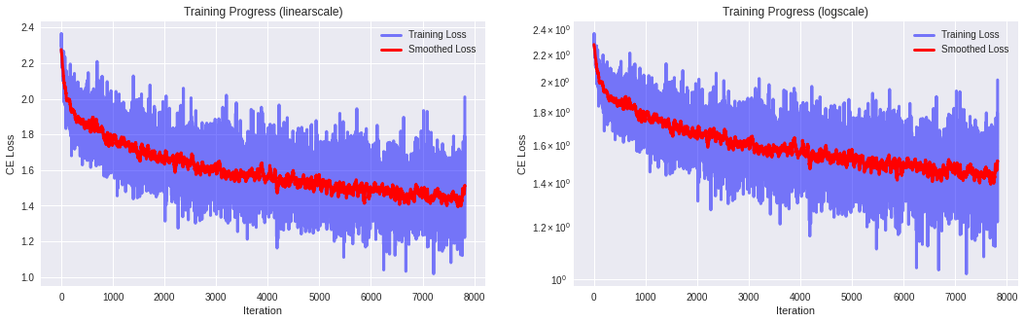

```python
plt.style.use('seaborn')
fig, ax = plt.subplots(1,2)
fig.set_size_inches(18,5)

smooth_loss = smooth(train_loss_per_pattern, 31)
ax[0].plot(train_loss_per_pattern, c="blue", label="Training Loss", linewidth=3, alpha=0.5)
ax[0].plot(smooth_loss, c="red", label="Smoothed Loss", linewidth=3)
ax[0].legend(loc="best")
ax[0].set_xlabel("Iteration")
ax[0].set_ylabel("CE Loss")
ax[0].set_title("Training Progress (linearscale)")

ax[1].plot(train_loss_per_pattern, c="blue", label="Training Loss", linewidth=3, alpha=0.5)
ax[1].plot(smooth_loss, c="red", label="Smoothed Loss", linewidth=3)
ax[1].legend(loc="best")
ax[1].set_xlabel("Iteration")
ax[1].set_ylabel("CE Loss")
ax[1].set_yscale("log")
ax[1].set_title("Training Progress (logscale)")

plt.show()
```

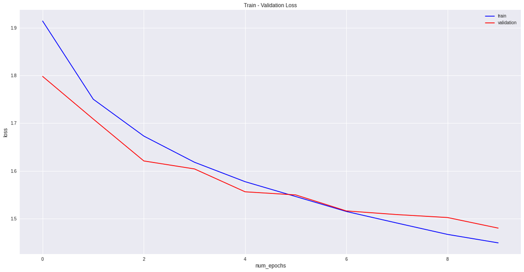

```python
# This plot show that the training loss is decreasing as go through the epochs, and it is learning well (no fluctuations/ no oscillations).
# The validation graph is somewhat between poor to good generalization

fig = plt.figure(figsize=(20,10))
plt.title("Train - Validation Loss")
plt.plot( train_loss_list, c="blue", label='train')
plt.plot( eval_loss_list, c="red", label='validation')
plt.xlabel('num_epochs', fontsize=12)
plt.ylabel('loss', fontsize=12)
plt.legend(loc='best')
```

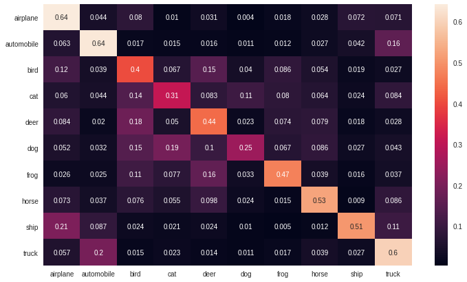

```python
from sklearn.metrics import confusion_matrix
import seaborn as sn
import pandas as pd

y_pred = []
y_true = []

# iterate over test data
for imgs, labels in eval_loader:
        # using GPU
        imgs, labels = imgs.to(device), labels.to(device)

        # forward pass
        flattened_imgs = imgs.flatten(start_dim=1)
        output = model(flattened_imgs)

        output = (torch.max(torch.exp(output), 1)[1]).data.cpu().numpy()
        y_pred.extend(output) # Save Prediction

        labels = labels.data.cpu().numpy()
        y_true.extend(labels) # Save Truth

# constant for classes
classes = ('airplane', 'automobile', 'bird', 'cat', 'deer', 'dog', 'frog', 'horse', 'ship', 'truck')

# Build confusion matrix
cf_matrix = confusion_matrix(y_true, y_pred)
df_cm = pd.DataFrame(cf_matrix/np.sum(cf_matrix) *10, index = [i for i in classes],
                     columns = [i for i in classes])
plt.figure(figsize = (12,7))
sn.heatmap(df_cm, annot=True)
plt.savefig('output.png')
```

**CNN Model**

```python
class CNN(nn.Module):
    """
    Varation of LeNet: a simple CNN model
    for handwritten digit recognition
    """
    def __init__(self):
        """ Model initializer """
        super().__init__()

        # layer 1
        # (3,32,32)
        conv1 = nn.Conv2d(in_channels=3, out_channels=6, kernel_size=5, stride=1, padding=0)
        # (6, 30, 30)
        relu1 = nn.ReLU()
        maxpool1 = nn.MaxPool2d(kernel_size=2)
        # (6, 15, 15)
        self.layer1 = nn.Sequential(
                conv1, relu1, maxpool1
            )

        # layer 2
        # (6, 15, 15)
        conv2 = nn.Conv2d(in_channels=6, out_channels=16,  kernel_size=5, stride=1, padding=0)
        # (16, 10, 10)
        relu2 = nn.ReLU()
        maxpool2 = nn.MaxPool2d(kernel_size=2)
        # (16, 5, 5)
        self.layer2 = nn.Sequential(
                conv2, relu2, maxpool2
            )

        # fully connected classifier
        in_dim = 16 * 5 * 5
        self.fc = nn.Linear(in_features=in_dim, out_features=10)

        return

    def forward(self, x):
        """ Forward pass """
        cur_b_size = x.shape[0]
        out1 = self.layer1(x)
        out2 = self.layer2(out1) # (B, 32, 4 ,4 ) -> (B, 32 * 4 * 4)
        out2_flat = out2.view(cur_b_size, -1)
        y = self.fc(out2_flat)
        return y

def count_model_params(model):
    """ Counting the number of learnable parameters in a nn.Module """
    num_params = sum(p.numel() for p in model.parameters() if p.requires_grad)
    return num_params
```

```python
cnn = CNN()
cnn
```

```
CNN(
  (layer1): Sequential(
    (0): Conv2d(3, 6, kernel_size=(5, 5), stride=(1, 1))
    (1): ReLU()
    (2): MaxPool2d(kernel_size=2, stride=2, padding=0, dilation=1, ceil_mode=False)
  )
  (layer2): Sequential(
    (0): Conv2d(6, 16, kernel_size=(5, 5), stride=(1, 1))
    (1): ReLU()
    (2): MaxPool2d(kernel_size=2, stride=2, padding=0, dilation=1, ceil_mode=False)
  )
  (fc): Linear(in_features=400, out_features=10, bias=True)
)
```

```python
params = count_model_params(cnn)
print(f"Model has {params} learnable parameters")
```

```
Model has 6882 learnable parameters
```

```python
device = torch.device("cuda" if torch.cuda.is_available() else "cpu")

cnn = cnn.to(device)
```

```python
cnn = cnn.to(device)
criterion = nn.CrossEntropyLoss().to(device)
optimizer = torch.optim.Adam(params=cnn.parameters(), lr=LR)
```

```python
@torch.no_grad()
def eval_model(model):
    """ Computing model accuracy """
    correct = 0
    total = 0
    loss_list = []

    for images, labels in eval_loader:
        images = images.to(device)
        labels = labels.to(device)

        # Forward pass only to get logits/output
        outputs = model(images)

        loss = criterion(outputs, labels)
        loss_list.append(loss.item())

        # Get predictions from the maximum value
        preds = torch.argmax(outputs, dim=1)
        correct += len( torch.where(preds==labels)[0] )
        total += len(labels)

    # Total correct predictions and loss
    accuracy = correct / total * 100
    loss = np.mean(loss_list)
    return accuracy, loss


def save_model(model, optimizer, epoch, stats):
    """ Saving model checkpoint """

    if(not os.path.exists("models")):
        os.makedirs("models")
    savepath = f"models/checkpoint_epoch_{epoch}.pth"

    torch.save({
        'epoch': epoch,
        'model_state_dict': model.state_dict(),
        'optimizer_state_dict': optimizer.state_dict(),
        'stats': stats
    }, savepath)
    return


def load_model(model, optimizer, savepath):
    """ Loading pretrained checkpoint """

    checkpoint = torch.load(savepath)
    model.load_state_dict(checkpoint['model_state_dict'])
    optimizer.load_state_dict(checkpoint['optimizer_state_dict'])
    epoch = checkpoint["epoch"]
    stats = checkpoint["stats"]

    return model, optimizer, epoch, stats
```

```python
def train_model(cnn,optimizer,criterion, l1_lambda=None):
    stats = {
    "epoch": [],
    "train_loss": [],
    "valid_loss": [],
    "accuracy": []
}
    init_epoch = 0

    LR = 3e-4
    EPOCHS = 10
    EVAL_FREQ = 1
    SAVE_FREQ = 10
    loss_hist = []
    for epoch in range(init_epoch, EPOCHS):
        loss_list = []
        progress_bar = tqdm(enumerate(train_loader), total=len(train_loader))
        for i, (images, labels) in progress_bar:
            images = images.to(device)
            labels = labels.to(device)

            # Clear gradients w.r.t. parameters
            optimizer.zero_grad()

            # Forward pass to get output/logits
            outputs = cnn(images)

            if l1_lambda==None:
                # Calculate Loss: softmax --> cross entropy loss
                loss = criterion(outputs, labels)
                loss_list.append(loss.item())
            else:
                l1_lambda = 0.001
                l1_norm = sum(p.abs().sum() for p in cnn.parameters())
                loss = criterion(outputs, labels) + l1_lambda*l1_norm
                loss_list.append(loss.item())

            # Getting gradients w.r.t. parameters
            loss.backward()

            # Updating parameters
            optimizer.step()
            progress_bar.set_description(f"Epoch {epoch+1} Iter {i+1}: loss {loss.item():.5f}. ")

        loss_hist.append(np.mean(loss_list))
        stats["epoch"].append(epoch)
        stats["train_loss"].append(loss_hist[-1])

        # evaluating model
        if epoch % EVAL_FREQ == 0:
            accuracy, valid_loss = eval_model(cnn)
            print(f"Accuracy at epoch {epoch}: {round(accuracy, 2)}%")
        else:
            accuracy, valid_loss = -1, -1
        stats["accuracy"].append(accuracy)
        stats["valid_loss"].append(valid_loss)

        # saving checkpoint
        if epoch % SAVE_FREQ == 0:
            save_model(model=cnn, optimizer=optimizer, epoch=epoch, stats=stats)
    return stats
```

```python
stats = train_model(cnn,optimizer,criterion)

accuracy, _ = eval_model(cnn)
print(f"Classification accuracy: {round(accuracy, 2)}%")
```

```
Accuracy at epoch 0: 28.94%
```

```
Accuracy at epoch 1: 34.15%
```

```
Accuracy at epoch 2: 37.36%
```

```
Accuracy at epoch 3: 39.84%
```

```
Accuracy at epoch 4: 41.28%
```

```
Accuracy at epoch 5: 43.15%
```

```
Accuracy at epoch 6: 44.43%
```

```
Accuracy at epoch 7: 45.78%
```

```
Accuracy at epoch 8: 45.96%
```

```
Accuracy at epoch 9: 46.62%
Classification accuracy: 46.62%
```

```python
epochs = np.array(stats["epoch"])
train_loss = np.array(stats["train_loss"])

eval_loss = np.array(stats["valid_loss"])
accuracy = np.array(stats["accuracy"])
eval_idx = np.where(eval_loss != -1)[0]
```

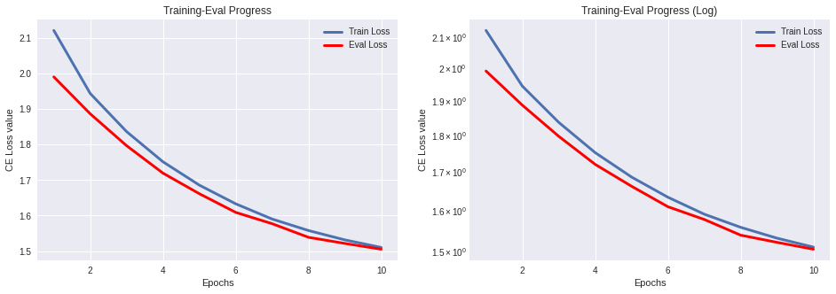

```python
fig, ax = plt.subplots(1,2)
fig.set_size_inches(16,5)

for a in ax:

    a.plot(epochs+1, train_loss, label="Train Loss", linewidth=3)
    a.plot(epochs[eval_idx]+1, eval_loss[eval_idx], c="red", label="Eval Loss", linewidth=3)
#     a.scatter(epochs[eval_idx]+1, eval_loss[eval_idx], c="red", s=100, marker="x")
    a.legend(loc="best")
    a.set_xlabel("Epochs")
    a.set_ylabel("CE Loss value")

ax[0].set_title("Training-Eval Progress")
ax[1].set_title("Training-Eval Progress (Log)")
ax[1].set_yscale("log")

plt.show()
```

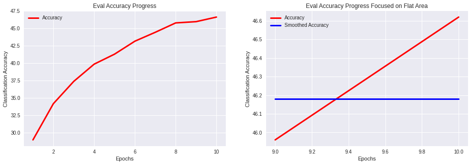

```python
fig, ax = plt.subplots(1,2)
fig.set_size_inches(16,5)

ax[0].plot(epochs[eval_idx]+1, accuracy[eval_idx], c="red", label="Accuracy", linewidth=3)
ax[0].legend(loc="best")
ax[0].set_xlabel("Epochs")
ax[0].set_ylabel("Classification Accuracy")
ax[0].set_title("Eval Accuracy Progress")

IDX = 8
zoomed = accuracy[IDX:]
filtered = smooth(zoomed, K=3)

ax[1].plot(epochs[IDX:]+1, accuracy[IDX:], c="red", label="Accuracy", linewidth=3)
ax[1].plot(epochs[IDX:]+1, filtered, c="blue", label="Smoothed Accuracy", linewidth=3)
ax[1].legend(loc="best")
ax[1].set_xlabel("Epochs")
ax[1].set_ylabel("Classification Accuracy")
ax[1].set_title("Eval Accuracy Progress Focused on Flat Area")

plt.show()
```

1. Visualize several convolutional kernels and activations from the first two convolutional layers

```python
def plot(tensor, plot_kernels, col_count=10):
    kernels_count = tensor.shape[0]
    row_count = 1+ kernels_count // col_count
    fig = plt.figure(figsize=(col_count,row_count))
    for i in range(kernels_count):
        axis = fig.add_subplot(row_count,col_count,i+1)
        if plot_kernels==False:
            axis.imshow(tensor[i],cmap='gray')
        else:
            axis.imshow(tensor[i][0,:,:].cpu(),cmap='gray')
        axis.set_xticklabels([])
        axis.set_yticklabels([])
        axis.axis('off')

    plt.subplots_adjust(wspace=0.3, hspace=0.3)
    plt.show()
```

```python
# Visualize several convolutional kernels and activations from the first two convolutional layers
```

```python
def visualize_kernals():
    filters = cnn.modules()
    cnn_layers = [i for i in cnn.children()]

    first_layer = cnn_layers[0][0]
    first_kernel = first_layer.weight.data.clone()

    second_layer = cnn_layers[1][0]
    second_kernel = second_layer.weight.data.clone()


    print(f"CNN first layer kernels with tensor shape {second_kernel.shape}")
    plot(first_kernel,True)

    print(f"CNN second layer kernels with tensor shape {first_kernel.shape}")
    plot(second_kernel,True)
```

```python
def visualize_activations():
    test_img = next(iter(eval_loader))[0][1].to(device)
    with torch.no_grad():
        print("Activation Visualization for first layer. This will return 6")
        filters = cnn.modules()
        cnn_layers = [i for i in cnn.children()]

        first_layer = cnn_layers[0][0]
        first_kernel = first_layer.weight.data.clone()

        second_layer = cnn_layers[1][0]
        second_kernel = second_layer.weight.data.clone()
        img_input = test_img.unsqueeze(0)
        result0 = first_layer(img_input)
        result0 = result0.squeeze()
        result1 = second_layer(result0)
        result1 = result1.squeeze()

    plot(result0.cpu().numpy(),False)

    print("Activation Visualization for seoond layer. This will return 16 channels.")
    plot(result1.cpu().numpy(),False)
```

```
CNN first layer kernels with tensor shape torch.Size([16, 6, 5, 5])
```

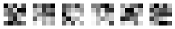

```
CNN second layer kernels with tensor shape torch.Size([6, 3, 5, 5])
```

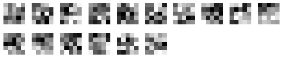

```python
visualize_kernals()
```

```
Activation Visualization for first layer. This will return 6
```

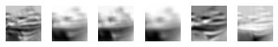

```
Activation Visualization for seoond layer. This will return 16 channels.
```

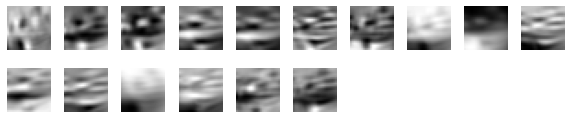

```python
visualize_activations()
```

1. Train CNNs without regularization, with L2-Regularization, and with L1-Regularization. Compare the results: training and validation loss, accuracy

```python
# This is to train the CNN with L1 regularization
```

```python
train_loader =  torch.utils.data.DataLoader(
        dataset=train_dataset,
        batch_size=BATCH_SIZE,
        shuffle=SHUFFLE_TRAIN
    )

eval_loader =  torch.utils.data.DataLoader(
        dataset=test_dataset,
        batch_size=BATCH_SIZE,
        shuffle=False
    )

cnn_l1 = CNN().to(device)
l1_criterion = nn.CrossEntropyLoss().to(device)
l1_optimizer = torch.optim.Adam(params=cnn_l1.parameters())
l1_stats = train_model(cnn_l1,l1_optimizer,l1_criterion,0.1)
```

```
Accuracy at epoch 0: 40.17%
```

```
Accuracy at epoch 1: 42.15%
```

```
Accuracy at epoch 2: 44.18%
```

```
Accuracy at epoch 3: 45.14%
```

```
Accuracy at epoch 4: 45.78%
```

```
Accuracy at epoch 5: 47.21%
```

```
Accuracy at epoch 6: 46.86%
```

```
Accuracy at epoch 7: 47.49%
```

```
Accuracy at epoch 8: 49.25%
```

```
Accuracy at epoch 9: 49.31%
```

```python
train_loader =  torch.utils.data.DataLoader(
        dataset=train_dataset,
        batch_size=BATCH_SIZE,
        shuffle=SHUFFLE_TRAIN
    )

eval_loader =  torch.utils.data.DataLoader(
        dataset=test_dataset,
        batch_size=BATCH_SIZE,
        shuffle=False
    )
cnn_l2 = CNN().to(device)
l2_criterion = nn.CrossEntropyLoss().to(device)
l2_optimizer = torch.optim.Adam(params=cnn_l2.parameters(),weight_decay=1e-5)
l2_stats = train_model(cnn_l2,l2_optimizer,l2_criterion)
```

```
Accuracy at epoch 0: 43.41%
```

```
Accuracy at epoch 1: 46.43%
```

```
Accuracy at epoch 2: 48.27%
```

```
Accuracy at epoch 3: 49.03%
```

```
Accuracy at epoch 4: 50.9%
```

```
Accuracy at epoch 5: 52.09%
```

```
Accuracy at epoch 6: 52.63%
```

```
Accuracy at epoch 7: 53.86%
```

```
Accuracy at epoch 8: 53.62%
```

```
Accuracy at epoch 9: 55.25%
```

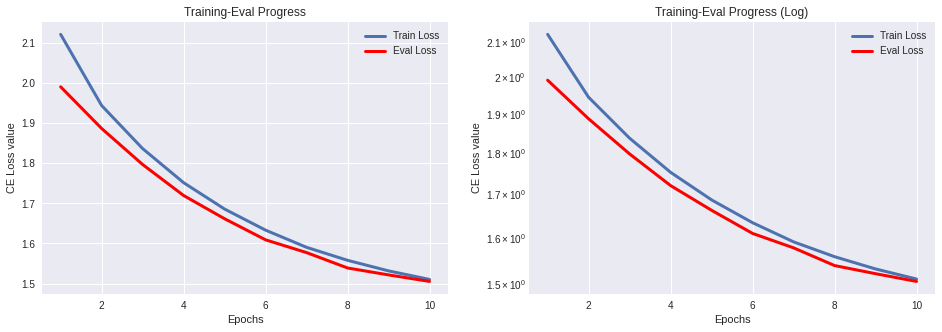

```python
fig, ax = plt.subplots(1,2)
fig.set_size_inches(16,5)

for a in ax:

    a.plot(epochs+1, train_loss, label="Train Loss", linewidth=3)
    a.plot(epochs[eval_idx]+1, eval_loss[eval_idx], c="red", label="Eval Loss", linewidth=3)
#     a.scatter(epochs[eval_idx]+1, eval_loss[eval_idx], c="red", s=100, marker="x")
    a.legend(loc="best")
    a.set_xlabel("Epochs")
    a.set_ylabel("CE Loss value")

ax[0].set_title("Training-Eval Progress")
ax[1].set_title("Training-Eval Progress (Log)")
ax[1].set_yscale("log")

plt.show()
```

```python
l1_epochs = np.array(l1_stats["epoch"])
l1_train_loss = np.array(l1_stats["train_loss"])

l1_eval_loss = np.array(l1_stats["valid_loss"])
l1_accuracy = np.array(l1_stats["accuracy"])
l1_eval_idx = l1_stats['epoch']
```

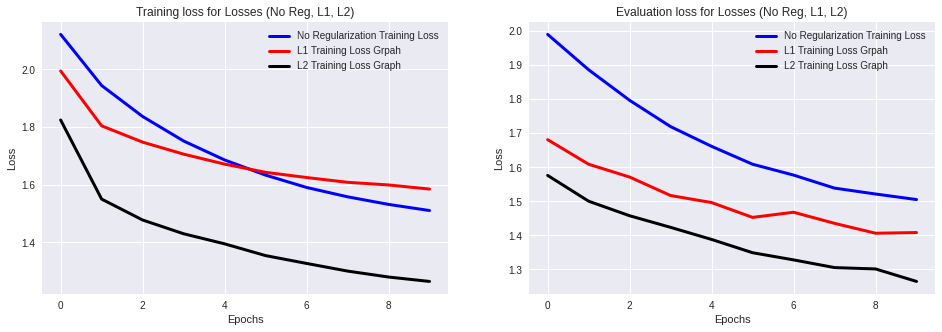

```python
l2_epochs = np.array(l2_stats["epoch"])
l2_train_loss = np.array(l2_stats["train_loss"])

l2_eval_loss = np.array(l2_stats["valid_loss"])
l2_accuracy = np.array(l2_stats["accuracy"])
l2_eval_idx = l2_stats['epoch']

fig, ax = plt.subplots(1,2)
fig.set_size_inches(16,5)

ax[0].plot(epochs, train_loss, c="blue", label="No Regularization Training Loss", linewidth=3)
ax[0].plot(l1_epochs, l1_train_loss, c="red", label="L1 Training Loss Grpah", linewidth=3)
ax[0].plot(l2_epochs, l2_train_loss, c="black", label="L2 Training Loss Graph", linewidth=3)
ax[0].legend(loc="best")
ax[0].set_xlabel("Epochs")
ax[0].set_ylabel("Loss")
ax[0].set_title("Training loss for Losses (No Reg, L1, L2)")

ax[1].plot(epochs[0:10], eval_loss, c="blue", label="No Regularization Training Loss", linewidth=3)
ax[1].plot(l1_epochs, l1_eval_loss, c="red", label="L1 Training Loss Grpah", linewidth=3)
ax[1].plot(l2_epochs, l2_eval_loss, c="black", label="L2 Training Loss Graph", linewidth=3)
ax[1].legend(loc="best")
ax[1].set_xlabel("Epochs")
ax[1].set_ylabel("Loss")
ax[1].set_title("Evaluation loss for Losses (No Reg, L1, L2)")


plt.show()
```

The above figure show that L2 regularization is better suited to this problem than L1 or no regularization at all.

This makes sense. L2 regularization tries to deal with outliers (the weights/neurons which can explode and affect the overall loss function). Features in these images are selected through cnn (so we don't really need the feature selection of L1 regularization).

The evaulation loss show how good L1 is generalizing compared to No regularization at all. This is because it tries to select features from already generated cnn feature and make sense on the new sparse features too. But, it is slower due to the fact that high value neurons are not punished exponentially as opposed to L2.

training and validation loss, accuracy

```python
import time
```

```python
class DropoutModel(nn.Module):
    """
    Varation of LeNet: a simple CNN model
    for handwritten digit recognition
    """
    def __init__(self, p=0.0):
        """ Model initializer """
        super().__init__()

        # layer 1
        # (3,32,32)
        conv1 = nn.Conv2d(in_channels=3, out_channels=6, kernel_size=5, stride=1, padding=0)
        # (6, 30, 30)
        relu1 = nn.ReLU()
        nn.Dropout(p)
        maxpool1 = nn.MaxPool2d(kernel_size=2)
        # (6, 15, 15)
        self.layer1 = nn.Sequential(
                conv1, relu1, maxpool1
            )

        # layer 2
        # (6, 15, 15)
        conv2 = nn.Conv2d(in_channels=6, out_channels=16,  kernel_size=5, stride=1, padding=0)
        # (16, 10, 10)
        relu2 = nn.ReLU()
        nn.Dropout(p)
        maxpool2 = nn.MaxPool2d(kernel_size=2)
        # (16, 5, 5)
        self.layer2 = nn.Sequential(
                conv2, relu2, maxpool2
            )

        # fully connected classifier
        in_dim = 16 * 5 * 5
        self.fc = nn.Linear(in_features=in_dim, out_features=10)

        return

    def forward(self, x):
        """ Forward pass """
        cur_b_size = x.shape[0]
        out1 = self.layer1(x)
        out2 = self.layer2(out1) # (B, 32, 4 ,4 ) -> (B, 32 * 4 * 4)
        out2_flat = out2.view(cur_b_size, -1)
        y = self.fc(out2_flat)
        return y

def count_model_params(model):
    """ Counting the number of learnable parameters in a nn.Module """
    num_params = sum(p.numel() for p in model.parameters() if p.requires_grad)
    return num_params
```

```python
def train_model(model: nn.Module, lr=3e-4) -> 'tuple[list, list, float]':
    #set the initial time
    t0 = time.time()
    loss_hist = []
    stats = {
    "epoch": [],
    "train_loss": [],
    "valid_loss": [],
    "accuracy": []
    }
    for epoch in range(init_epoch, EPOCHS):
        loss_list = []
        progress_bar = tqdm(enumerate(train_loader), total=len(train_loader))
        for i, (images, labels) in progress_bar:
            images = images.to(device)
            labels = labels.to(device)

            # Clear gradients w.r.t. parameters
            optimizer.zero_grad()

            # Forward pass to get output/logits
            outputs = cnn(images)

            # Calculate Loss: softmax --> cross entropy loss
            loss = criterion(outputs, labels)
            loss_list.append(loss.item())

            # Getting gradients w.r.t. parameters
            loss.backward()

            # Updating parameters
            optimizer.step()
            progress_bar.set_description(f"Epoch {epoch+1} Iter {i+1}: loss {loss.item():.5f}. ")

        loss_hist.append(np.mean(loss_list))
        stats["epoch"].append(epoch)
        stats["train_loss"].append(loss_hist[-1])

        # evaluating model
        if epoch % EVAL_FREQ == 0:
            accuracy, valid_loss = eval_model(cnn)
            print(f"Accuracy at epoch {epoch}: {round(accuracy, 2)}%")
        else:
            accuracy, valid_loss = -1, -1
        stats["accuracy"].append(accuracy)
        stats["valid_loss"].append(valid_loss)

    return stats["valid_loss"], stats["accuracy"], time.time() - t0
```

```python
LR = 3e-4
EPOCHS = 10
EVAL_FREQ = 1
SAVE_FREQ = 10
stats = {
    "epoch": [],
    "train_loss": [],
    "valid_loss": [],
    "accuracy": []
}
init_epoch = 0
```

```python
#training the model without dropout
dropout_model_0 = DropoutModel().to(device)
dropout_loss_0, dropout_accuracy_0, dropout_time_0 = train_model(dropout_model_0)
```

```
Accuracy at epoch 0: 47.2%
```

```
Accuracy at epoch 1: 48.03%
```

```
Accuracy at epoch 2: 47.96%
```

```
Accuracy at epoch 3: 48.54%
```

```
Accuracy at epoch 4: 48.54%
```

```
Accuracy at epoch 5: 49.03%
```

```
Accuracy at epoch 6: 48.91%
```

```
Accuracy at epoch 7: 49.78%
```

```
Accuracy at epoch 8: 50.13%
```

```
Accuracy at epoch 9: 49.6%
```

```python
#training the model with dropout
dropout_model_1 = DropoutModel(0.25).to(device)
dropout_loss_1, dropout_accuracy_1, dropout_time_1 = train_model(dropout_model_1)
```

```
Accuracy at epoch 0: 50.04%
```

```
Accuracy at epoch 1: 49.77%
```

```
Accuracy at epoch 2: 50.83%
```

```
Accuracy at epoch 3: 50.58%
```

```
Accuracy at epoch 4: 50.89%
```

```
Accuracy at epoch 5: 50.84%
```

```
Accuracy at epoch 6: 51.05%
```

```
Accuracy at epoch 7: 51.62%
```

```
Accuracy at epoch 8: 51.59%
```

```
Accuracy at epoch 9: 52.05%
```

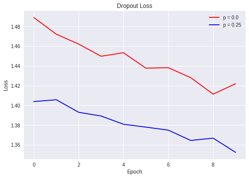

```
66.36168146133423
```

```python
#plotting the dropout loss curves
plt.plot(dropout_loss_0, c='red', label='p = 0.0')
plt.plot(dropout_loss_1, c='blue', label='p = 0.25')
plt.title('Dropout Loss')
plt.xlabel('Epoch')
plt.ylabel('Loss')
plt.legend()
plt.show()
dropout_time_0
```

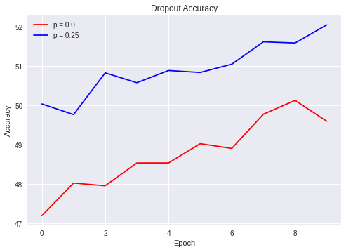

```
68.93824100494385
```

```python
#plotting the dropout aacuracy curves
plt.plot(dropout_accuracy_0, c='red', label='p = 0.0')
plt.plot(dropout_accuracy_1, c='blue', label='p = 0.25')
plt.title('Dropout Accuracy')
plt.xlabel('Epoch')
plt.ylabel('Accuracy')
plt.legend()
plt.show()
dropout_time_1
```